# Estimación paramétrica

Authors

Affiliations

Félix Belzunce

Universidad de Murcia

María del Carmen Bueso, Pilar Sanmartín

Universidad Politécnica de Cartagena

## Introducción

El objetivo de esta práctica es afianzar la comprensión de los conceptos asociados a la estimación puntual de parámetros, las propiedades de los estimadores así como de su distribución muestral.

Compararemos dos métodos de estimación para un modelo asociado a la distribución gamma.

## El modelo

Consideramos una muestra aleatoria simple $X_1,\cdots, X_n$ de una distribución gamma de parámetros $\alpha$ y $\beta$.

**Recordatorio sobre la distribución gamma**

La familia gamma de distribuciones es una familia parametrizada por dos parámetros $\alpha > 0$ y $\beta >0$, que admite por función de densidad:

$$f(x;\alpha, \beta) = \frac 1 {\Gamma(\alpha)\beta^\alpha} x^{\alpha - 1}e^{-x/\beta}, 0<x<\infty.$$

La función $\Gamma$ está definida por

$$\Gamma(\alpha) = \int_0^{+\infty}t^{\alpha - 1} e^{-t}dt, \alpha>0,$$

y es fácil demostrar que cumple

$$\Gamma(\alpha + 1) = \alpha\Gamma(\alpha).$$

## Generación de las muestras simuladas de observaciones

En este apartado, nos disponemos a simular muestras de valores de una distribución gamma de parámetros $\alpha$ y $\beta$ que podremos fijar.  
Podremos decidir el tamaño de las m.a.s. que vamos a simular, es decir, el valor de $n$ de la m.a.s. $X_1,\cdots, X_n$ y también del número total de muestras `n_muestras` que necesitamos.

Siguiendo el procedimiento usado en la práctica sobre distribución en el muestreo, escribid una función `simular_muestras` que admita como parámetros `n_muestras`, `n`, `alpha`, `beta` y que devuelva una lista con `n_muestras` elementos que son vectores de $n$ valores simulados de la distribución gamma$(\alpha, \beta)$.

```r
library(tidyverse)
simular_muestras <- function(n_muestras, n, alpha, beta){
# Completar aquí
  replicate(n_muestras,
    rgamma(n, shape = alpha, scale = beta),
    simplify = FALSE
  )
# Fin Completar aquí
}
set.seed(314159)
simular_muestras(n_muestras = 5, n = 4, alpha = 3, beta = 2)
```

```
[[1]]
[1] 2.791858 4.317136 6.011088 3.822595

[[2]]
[1] 3.982836 2.847772 1.348328 1.165540

[[3]]
[1] 3.498571 1.099349 3.557430 9.501783

[[4]]
[1] 9.093030 2.021994 5.618795 4.981685

[[5]]
[1] 5.307337 8.205156 7.896792 8.264641
```

## Estimación usando el método de los momentos

### Cálculo de los momentos

$$E[X] = \alpha\beta,$$

$$\hat\alpha = \frac{(\bar{X})^2}{\overline{X^2} - (\bar{X})^2}, \tag{1}$$

$$\hat\beta = \frac{\overline{X^2} - (\bar{X})^2}{\bar{X}}.$$

### Implementación del cálculo de los estimadores

Implementad una función llamada `calcular_estimadores_momentos` que admita como parámetros el valor de una m.a.s., es decir $x =(x_1, \cdots, x_n)$ y que devuelva un tibble (o un dataframe) con dos columnas, llamadas `alphahat` y `betahat`, y una fila, con los valores estimados de $\alpha$ y $\beta$.

```r
library(tibble)


calcular_estimadores_momentos <- function(x){
# Completar aquí
  # Calcular las medias necesarias
  media_X <- mean(x)
  media_X2 <- mean(x^2)

  # Calcular los estimadores de α y β usando las fórmulas proporcionadas
  alphahat <- (media_X)^2 / (media_X2 - (media_X)^2)
  betahat <- (media_X2 - (media_X)^2) / media_X
  tibble(alphahat = alphahat, betahat = betahat)
# Fin Completar aquí
}
x <- c(2.79, 4.32, 6.01, 3.82, 3.98, 2.85, 1.35, 1.17, 3.50, 1.10)
calcular_estimadores_momentos(x) %>%
  mutate(across(everything(), round, 2))
```

```
# A tibble: 1 × 2
  alphahat betahat
     <dbl>   <dbl>
1     4.27    0.72
```

### Cálculo de los valores de los estimadores para las muestras simuladas

- Usando la función `simular_muestras` definida anteriormente, cread la lista `lista_muestras`, con valores simulados especificando `n_muestras= 5, n = 100, alpha = 3, beta = 2`.
- A continuación, obtened un tibble con dos columnas llamadas `alphahat` y `betahat`, y `n_muestras` filas. Cada una de sus filas contiene los valores estimados con el método de los momentos de $\alpha$ y $\beta$ para las `n_muestras` muestras. LLamaréis este tibble resultado `valores_estimadores`.

**Pro tips**

- Tendréis que usar `map_dfr` de `purrr` que aplica una función a una lista devolviendo un dataframe.
- Procurad usar un pipe!

```r
library(purrr)
set.seed(314159)
# Completar aquí
lista_muestra <- simular_muestras(n_muestras = 5, n = 100, alpha = 3, beta = 2)
lista_muestra
```

[output not shown]

[output cut: 79 more lines]

```r
valores_estimadores <- lista_muestra |>
  map_dfr(~ calcular_estimadores_momentos(.)) |>
  mutate(across(everything(), round, 2))
  # Fin Completar aquí
valores_estimadores
```

```
# A tibble: 5 × 2
  alphahat betahat
     <dbl>   <dbl>
1     2.26    2.55
2     3.21    1.88
3     2.52    2.34
4     2.38    2.59
5     2.48    2.14
```

### Evolución del sesgo y del varianza de los estimadores

#### Cálculo del sesgo y del error cuadrático medio (MSE)

El sesgo se define como la diferencia entre la esperanza del estimador y el valor real del parámetro. Como estamos en una situación de simulación, podemos calcular una aproximación del sesgo calculando la diferencia entre el promedio de los valores simulados del estimador $\hat{\theta}_{1},\cdots,\hat{\theta}_k$ , $k=$n_muestras y el valor real del parámetro:

$$\frac{1}{k}\sum_{i=1}^{k}(\hat{\theta}_i-\theta).$$

El error cuadrático medio (Mean Square Error, MSE) evalúa la dispersión de la distribución muestral del estimador respecto al valor real del parámetro. Se define como

$$MSE(\hat{\theta}) = E_\theta[(\hat{\theta} - \theta)^2],$$

para un estimador $\hat{\theta}$ del parámetro $\theta$, la esperanza se calcula usando la distribución con valor del parámetro $\theta$.  
Al igual que para el sesgo, lo aproximaremos usando el promedio de las diferencias al cuadrado entre los valores del estimador y el valor real del parámetro:

$$\frac{1}{k}\sum_{i=1}^{k}(\hat{\theta}_i-\theta)^2.$$

Usando la instrucción `summarise` de la librería `dplyr` que está incluida en `tidyverse`, escribid una función llamada `calcular_sesgo_mse` que admita como parámetros:

- un tibble `valores_estimadores` con los valores calculados de los estimadores de $\alpha$ y $\beta$, resultado del apartado anterior,
- los valores `alpha_real` y `beta_real` que son los valores de los parámetros que hemos usado en las simulaciones y que buscamos estimar.

La función devolverá un tibble con cuatro columnas `sesgo_alpha`, `mse_alpha`, `sesgo_beta`, `mse_beta`.

```r
# Completar aquí

calcular_sesgo_mse <- function(valores_estimadores, alpha_real, beta_real) {
  valores_estimadores |>
    summarise(
      sesgo_alpha = mean(alphahat - alpha_real),
      mse_alpha = mean((alphahat - alpha_real)^2),
      sesgo_beta = mean(betahat - beta_real),
      mse_beta = mean((betahat - beta_real)^2)
    )
}

# Fin Completar aquí
valores_estimadores |>
    calcular_sesgo_mse(alpha_real = 3, beta_real = 2)
```

```
# A tibble: 1 × 4
  sesgo_alpha mse_alpha sesgo_beta mse_beta
        <dbl>     <dbl>      <dbl>    <dbl>
1       -0.43     0.295        0.3    0.160
```

#### Evolución del sesgo y MSE si el tamaño de la muestra crece

Queremos comprobar la evolución del sesgo y del MSE si aumenta el tamaño muestral. Recompilando lo hecho en las secciones anteriores, calculad sesgo y mse para los estimadores calculados con el método de los momentos para $\alpha$ y $\beta$, considerando `n_muestras = 10000`, $\alpha = 3, \beta = 2$, y usando los tamaños muestrales $n = 10, 100, 1000$ y $10000$.

Para ello, podréis definir una función `calcular_flujo_completo` que admita como parámetros `n_muestras, n, alpha_real, beta_real`, y como parámetro la función `calcular_estimadores`, que recapitule los tres pasos que hemos seguido en el procedimiento hasta el momento (simular muestras, calcular los estimadores para las muestras, calcular el sesgo y el mse). Añadimos al dataframe una columna `n` para registrar el tamaño muestral considerado.

```r
set.seed(314159)
# Completar aquí

calcular_flujo_completo <- function(n_muestras, n, alpha_real, beta_real, fun) {
  # Simular muestras
  lista_muestras <- simular_muestras(n_muestras = n_muestras, n = n, alpha = alpha_real, beta = beta_real)

  # Calcular estimadores para cada muestra
  valores_estimadores <- lista_muestras %>%
    map_dfr(~ calcular_estimadores_momentos(.))

  # Calcular el sesgo y el MSE
  resultados <- calcular_sesgo_mse(valores_estimadores, alpha_real, beta_real)

  # Agrupar el tamaño de muestra como una columna
  resultados <- resultados %>%
    mutate(n = n)

  resultados
}

# Fin Completar aquí
calcular_flujo_completo(
    n_muestras = 10000,
    n  = 10,
    alpha_real = 3,
    beta_real = 2,
    calcular_estimadores_momentos
)
```

```
# A tibble: 1 × 5
  sesgo_alpha mse_alpha sesgo_beta mse_beta     n
        <dbl>     <dbl>      <dbl>    <dbl> <dbl>
1        1.41      8.64     -0.248    0.969    10
```

En la celda siguiente, se crea un dataframe con los valores de sesgo y mse para los distintos valores de $n$, se aprovecha la función `map_dfr` de la librería `purrr`, y la notación para funciones anónimas (el segundo argumento de `map_dfr`) de esa misma librería. Podéis consultar la “cheat sheet” de `purrr` en este [enlace](https://github.com/rstudio/cheatsheets/blob/main/purrr.pdf).

```r
set.seed(314159)
# Guardos estos datos a modo de variable
resultados2 <- map_dfr(
    c(10, 50, 100, 500, 1000, 5000, 10000, 20000), # Agregando más valores para n
    \(n)   calcular_flujo_completo(
               n_muestras = 10000,
               n  = n,
               alpha_real = 3,
               beta_real = 2,
               calcular_estimadores_momentos
           )
)
```

Comprobamos cómo el sesgo y el MSE decrecen rápidamente al aumentar $n$. Por lo que las simulaciones parecen indicar que ambos estimadores son consistentes.

**Opcional: representación gráfica**

¿Podríais representar gráficamente la evolución del sesgo para cada uno de los estimadores?

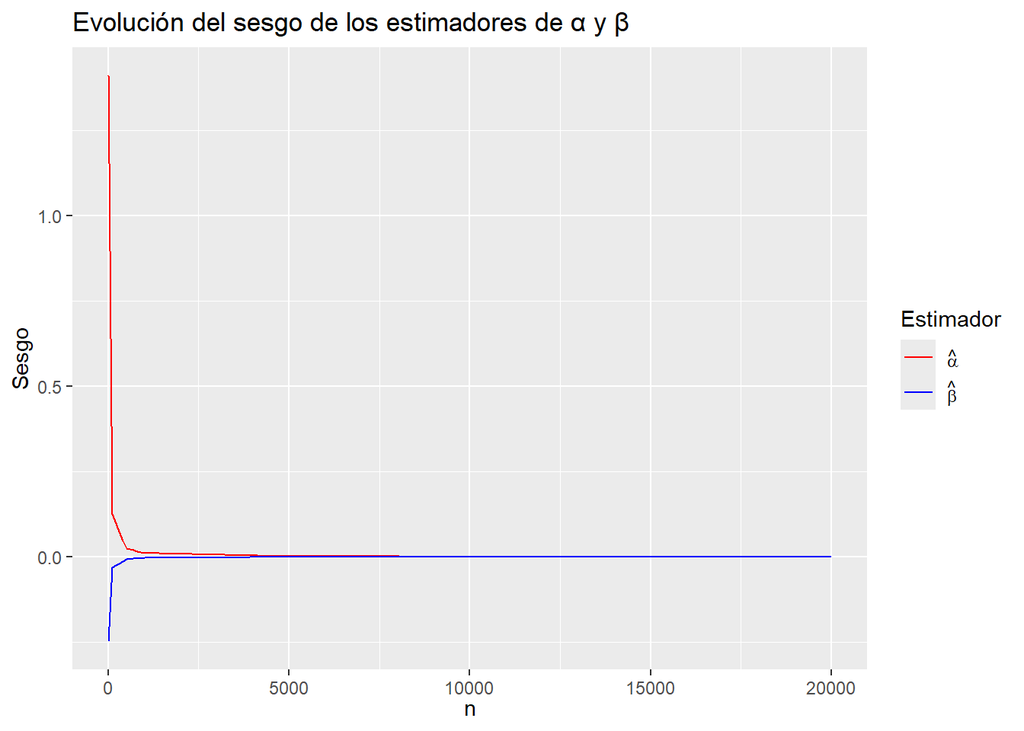

```r
# Expandir y limpiar el DataFrame con los nombres correctos de los estimadores
resultados_long <- resultados2 %>%
  pivot_longer(cols = starts_with("sesgo"), names_to = "estimador", values_to = "sesgo") %>%
  filter(estimador %in% c("sesgo_alpha", "sesgo_beta")) %>%
  mutate(estimador = recode(estimador, "sesgo_alpha" = "alpha_hat", "sesgo_beta" = "beta_hat"))

# Crear un rango expandido de valores de 'n' para interpolar
n_expanded <- seq(min(resultados_long$n), max(resultados_long$n), length.out = 200)

# Realizar la interpolación en el sesgo para cada estimador y 'n' expandido
resultados_long_expanded <- resultados_long %>%
  group_by(estimador) %>%
  do(data.frame(n = n_expanded, sesgo = approx(.$n, .$sesgo, xout = n_expanded, method = "linear", rule = 2)$y)) %>%
  ungroup()

ggplot(resultados_long_expanded, aes(x = n, y = sesgo, color = estimador)) +
    geom_line() +
    scale_color_manual(
        values = c("alpha_hat" = "red", "beta_hat" = "blue"),
        labels = c("alpha_hat" = expression(hat(alpha)), "beta_hat" = expression(hat(beta)))
    ) +
    labs(
        title = "Evolución del sesgo de los estimadores de α y β",
        x = expression(n),
        y = "Sesgo",
        color = "Estimador"
    )
```

## Método de máxima verosimilitud

### Cálculo de la verosimilitud

En el problema 9 de la relación de problemas, hemos demostrado que la log-verosimilitud (el logaritmo de la verosimilitud) para $(\alpha, \beta)$ asociada a una m.a.s. $X_1, \cdots, X_n$ de una distribución gamma$(\alpha, \beta)$ es:

$$\log L_n(\alpha, \beta) = n(\alpha - 1)\overline{\log x} - n\log \Gamma(\alpha) - n\alpha\log \beta - n\bar{x} / \beta,$$

donde $\overline{\log x} = \frac 1 n \sum_{i =1}^n \log x_i$.

### Cálculo del estimador de máxima verosimilitud

También hemos deducido que, para un valor de $\alpha$ fijado, el valor de $\beta$ que maximiza la log-verosimilitud es:

$$\hat{\beta} = \bar{x} / \alpha.$$

Por consiguiente, podemos encontrar el estimador de máxima verosimilitud en dos pasos:

1. Encontramos el valor $\hat{\alpha}$ que maximiza $\alpha\mapsto \log L(\alpha, \bar{x}/ \alpha)$.
2. Calculamos
   $$\hat{\beta} = \bar{x} / \hat{\alpha}.$$

En la asignatura de “Optimización” del primer cuatrimestre, veréis varios algoritmos de maximización para llevar a cabo el primer paso. En nuestro caso, usaremos la función `optimize`en `R`, que lleva a cabo la optimización de una función de una variable en un intervalo.

#### Primer paso: maximización de la log-verosimilitud parcial $\alpha\mapsto \log L(\alpha, \bar{x}/ \alpha)$

Definir una función llamada `calcular_logverosimilitud_alpha`, que admita como parámetros `alpha` y `x`, el vector de observaciones, y que devuelva $\log L(\alpha, \bar{x}/ \alpha)$.

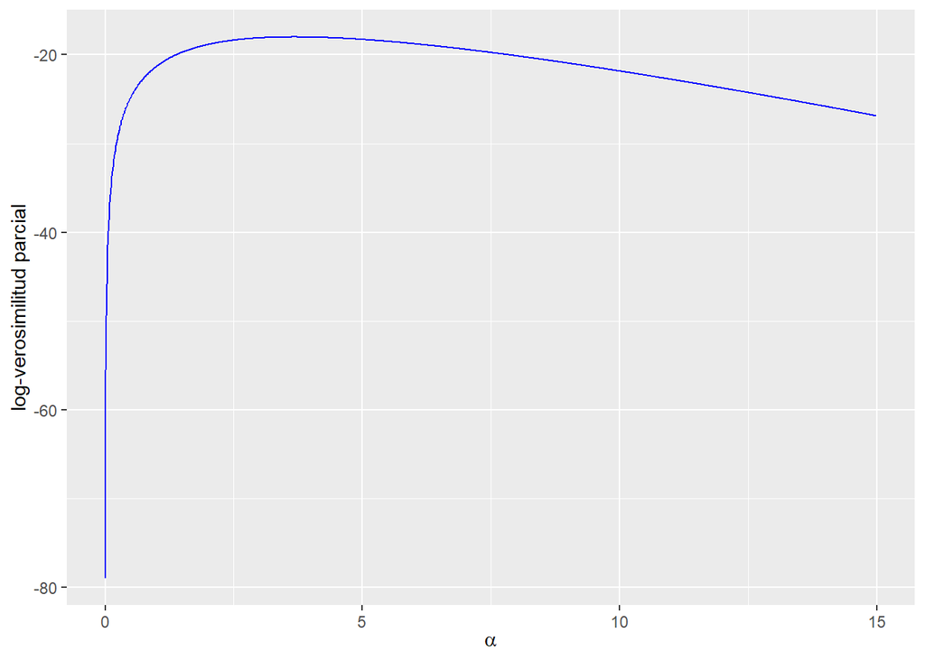

```r
# Completar aquí

calcular_logverosimilitud_alpha <- function(alpha, x) {
  n <- length(x)
  x_bar <- mean(x)
  log_x_bar <- mean(log(x))
  beta <- x_bar / alpha

  # Calcular la log-verosimilitud parcial usando beta = x_bar / alpha
  log_L_alpha <- n * (alpha - 1) * log_x_bar - n * lgamma(alpha) - n * alpha * log(beta) - n * x_bar / beta

  return(log_L_alpha)
}

# Fin Completar aquí
x <- c(2.79, 4.32, 6.01, 3.82, 3.98, 2.85, 1.35, 1.17, 3.50, 1.10)
tibble(
    alpha = seq(0.001, 15, by = 0.01),
    ll = calcular_logverosimilitud_alpha(alpha, x)
) |>
    ggplot(aes(x = alpha, y = ll)) +
    geom_line(col = "blue") +
    labs(x = expression(alpha), y = "log-verosimilitud parcial")
```

Para usar `optimize`, necesitamos proporcionar la función que queremos optimizar, un intervalo donde buscar el óptimo, y especificar que buscamos un máximo.

Para especificar el intervalo, podemos empezar en 0 hasta dos veces el estimador de $\alpha$ que obtuvimos por el método de los momentos, por ejemplo, ver Equation 1.

Como resultado obtenemos el valor en el que se alcanza el máximo ($maximum) y el valor de la función en este punto ($objective).

```r
alpha0 <-  (mean(x))^2 / (mean(x^2) - (mean(x))^2)
optimize(
    \(alpha) calcular_logverosimilitud_alpha(alpha = alpha, x),
    interval = c(0, 2 * alpha0),
    maximum = TRUE
)
```

```
$maximum
[1] 3.675222

$objective
[1] -17.9894
```

Definid una función `calcular_estimadores_mv`, con la misma estructura que la función `calcular_estimadores_momentos`, que devuelva los valores de los estimadores de máxima verosimilitud, aprovechando `optimize`, tal como lo acabamos de ver.

```r
# Completar aquí

# Definir la función para calcular los estimadores de máxima verosimilitud
calcular_estimadores_mv <- function(x) {
  alpha0 <- (mean(x))^2 / (mean(x^2) - (mean(x)^2))
  if (alpha0 <= 0) alpha0 <- 1e-3  # Ajustar alpha0 si es menor o igual a cero
  alphahat <- optimise(
    function(alpha) calcular_logverosimilitud_alpha(alpha = alpha, x),
    interval = c(1e-3, 2 * alpha0),  # Evitar el límite inferior igual a cero
    maximum = TRUE
  )$maximum

  # Ajustar alphahat si es menor o igual a cero
  if (alphahat <= 0) alphahat <- 1e-3

  # Devolver los estimadores en un tibble
  tibble(
    alphahat = alphahat,
    betahat = mean(x) / alphahat
  )
}

# Fin Completar aquí
x <- c(2.79, 4.32, 6.01, 3.82, 3.98, 2.85, 1.35, 1.17, 3.50, 1.10)
calcular_estimadores_mv(x)
```

```
# A tibble: 1 × 2
  alphahat betahat
     <dbl>   <dbl>
1     3.68   0.840
```

```r
set.seed(314159)
# Completar aquí
estimadores <- calcular_estimadores_mv(x)
map_dfr(
    c(10, 100, 1000, 1000), # Agregando más valores para n
    \(n)   calcular_flujo_completo(
               n_muestras = 10000,
               n  = n,
               alpha_real = estimadores$alphahat,
               beta_real = estimadores$betahat,
               calcular_estimadores_momentos
           )
)
```

```
# A tibble: 4 × 5
  sesgo_alpha mse_alpha sesgo_beta mse_beta     n
        <dbl>     <dbl>      <dbl>    <dbl> <dbl>
1      1.70     13.1     -0.101     0.170      10
2      0.146     0.384   -0.0117    0.0196    100
3      0.0163    0.0349  -0.00192   0.00199  1000
4      0.0117    0.0350  -0.000418  0.00200  1000
```

```r
# Fin Completar aquí
```

Comparad los resultados obtenidos con los de los estimadores con el método de los momentos. ¿Qué conclusiones sacáis?

## Por si os interesa

Podríamos haber hecho los cálculos con ambos métodos en una única función llamada a `map_dfr`, para ello generamos una lista con todas las combinaciones de `n`, y de los dos métodos. Aquí está el código por si os interesa. Usa varias funciones del conjunto de paquetes del tidyverse.

```r
set.seed(314159)
parameters <- expand_grid(
    n = c(10, 100, 1000, 10000),
    tibble(
        fn_metodo = c(calcular_estimadores_momentos, calcular_estimadores_mv),
        metodo = c("Método de los momentos", "Máxima verosimilitud")
    )
)
parameters <-  parameters |>
    split(1:nrow(parameters))
map_dfr(
    parameters,
    \(par)   calcular_flujo_completo(
               n_muestras = 10000,
               n  = par$n,
               alpha_real = 3,
               beta_real = 2,
               par$fn_metodo
             ) |>
             transform(metodo = par$metodo)
)
```

```
   sesgo_alpha   mse_alpha    sesgo_beta    mse_beta     n
1 1.4112980245 8.643637884 -2.480028e-01 0.968903984    10
2 1.4347801516 8.953779227 -2.648919e-01 0.937722925    10
3 0.1235862030 0.273122383 -2.734629e-02 0.119284134   100
4 0.1246201005 0.263610796 -3.165999e-02 0.114436981   100
5 0.0134841787 0.024550073 -3.952208e-03 0.012020809  1000
6 0.0110745729 0.024270223 -1.711983e-03 0.011861274  1000
7 0.0011442708 0.002383280 -2.162201e-04 0.001201928 10000
8 0.0007735032 0.002385491  5.477773e-05 0.001189127 10000
                  metodo
1 Método de los momentos
2   Máxima verosimilitud
3 Método de los momentos
4   Máxima verosimilitud
5 Método de los momentos
6   Máxima verosimilitud
7 Método de los momentos
8   Máxima verosimilitud
```